# Formatting axis labels

Author

Charlotte Soneson, Michael Stadler

## Summary

This document provides some examples of how to format various types of labels in `ggplot2` plots.

## Prepare data

Run the following code to load the packages and data that are used in this document:

```r
suppressPackageStartupMessages({
    library(dplyr)
    library(tibble)
    library(swissknife)
    library(ggplot2)
    library(ggtext)
    library(ggrepel)
})

loadExampleData("mycars")
```

```
`mycars`: re-encoded version of `datasets::mtcars`
```

```r
mycars <- mycars |>
    rownames_to_column("model")

tibble(mycars)
```

```
# A tibble: 32 × 14
   model         mpg cyl    disp    hp  drat    wt  qsec    vs    am  gear  carb
   <chr>       <dbl> <fct> <dbl> <dbl> <dbl> <dbl> <dbl> <dbl> <dbl> <dbl> <dbl>
 1 Mazda RX4    21   6      160    110  3.9   2.62  16.5     0     1     4     4
 2 Mazda RX4 …  21   6      160    110  3.9   2.88  17.0     0     1     4     4
 3 Datsun 710   22.8 4      108     93  3.85  2.32  18.6     1     1     4     1
 4 Hornet 4 D…  21.4 6      258    110  3.08  3.22  19.4     1     0     3     1
 5 Hornet Spo…  18.7 8      360    175  3.15  3.44  17.0     0     0     3     2
 6 Valiant      18.1 6      225    105  2.76  3.46  20.2     1     0     3     1
 7 Duster 360   14.3 8      360    245  3.21  3.57  15.8     0     0     3     4
 8 Merc 240D    24.4 4      147.    62  3.69  3.19  20       1     0     4     2
 9 Merc 230     22.8 4      141.    95  3.92  3.15  22.9     1     0     4     2
10 Merc 280     19.2 6      168.   123  3.92  3.44  18.3     1     0     4     4
# ℹ 22 more rows
# ℹ 2 more variables: engine_shape <fct>, transmission <fct>
```

## Construct basic plot

Using the `mycars` data, create the following basic plot.

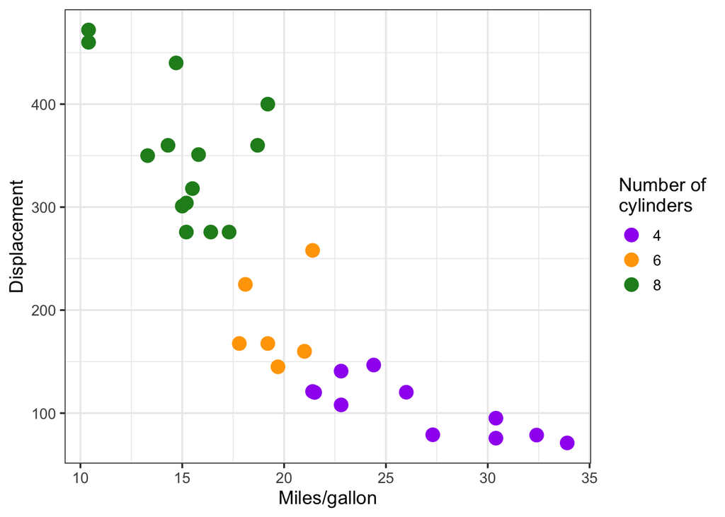

```r
ggplot(mycars,
       aes(x = mpg, y = disp, color = cyl)) +
    geom_point(size = 4) +
    scale_color_manual(values = c(`4` = "purple", `6` = "orange",
                                  `8` = "forestgreen"),
                       name = "Number of\ncylinders") +
    labs(x = "Miles/gallon", y = "Displacement") +
    theme_bw(base_size = 13)
```

## Add labels to points

The first extension we will make to the basic plot is to add a label to each point. We will use the `model` column. Note that the labels are added in such a way that they do not overlap (more precisely, different labels are designed to repel each other to avoid overlaps whenever possible).

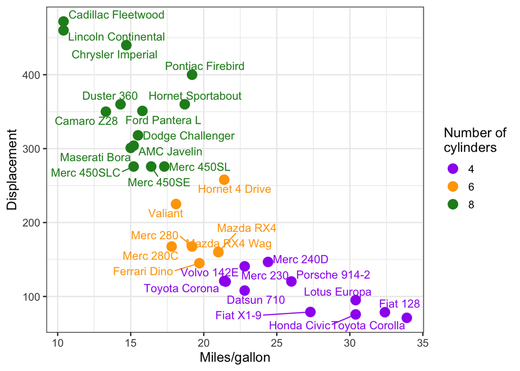

```r
ggplot(mycars,
       aes(x = mpg, y = disp, color = cyl, label = model)) +
    geom_point(size = 4) +
    geom_text_repel(min.segment.length = 0, max.overlaps = Inf) +
    scale_color_manual(values = c(`4` = "purple", `6` = "orange",
                                  `8` = "forestgreen"),
                       name = "Number of\ncylinders") +
    labs(x = "Miles/gallon", y = "Displacement") +
    theme_bw(base_size = 13)
```

## Format axis labels using markdown

Next, we turn our attention to the axis labels. The `ggtext` package provides functionality to format the axes (or other text elements) using *markdown*. Use this functionality to add formatting (italics and bold) to the x-axis title, and add a unit to the y-axis title (here, it is helpful to note that HTML code can be interpreted by markdown).

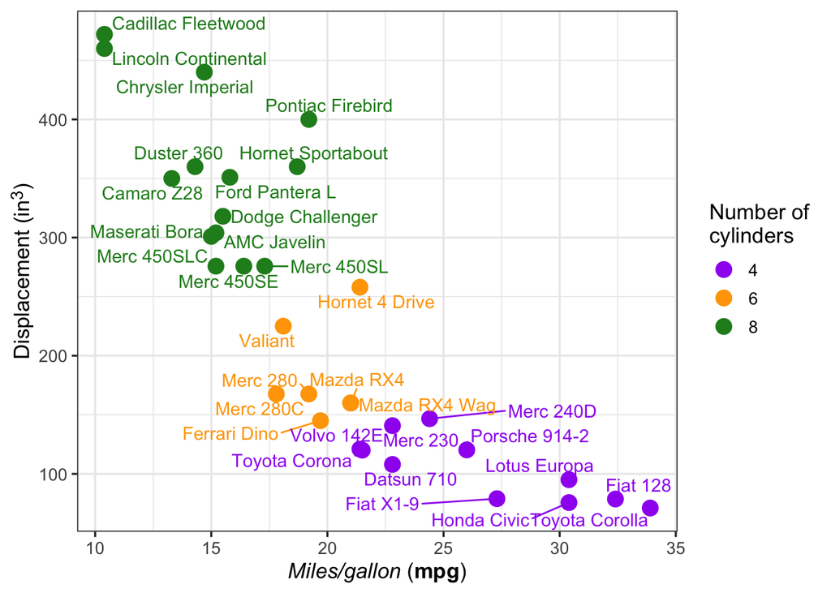

```r
ggplot(mycars,
       aes(x = mpg, y = disp, color = cyl, label = model)) +
    geom_point(size = 4) +
    geom_text_repel(min.segment.length = 0, max.overlaps = Inf) +
    scale_color_manual(values = c(`4` = "purple", `6` = "orange",
                                  `8` = "forestgreen"),
                       name = "Number of\ncylinders") +
    labs(x = "_Miles/gallon_ (**mpg**)", y = "Displacement (in<sup>3</sup>)") +
    theme_bw(base_size = 13) +
    theme(axis.title.x.bottom = element_markdown(),
          axis.title.y.left = element_markdown())
```

## Add special characters to labels

Next, we will change the axis titles completely (the x-axis title to $\alpha$, and the y-axis title to $\beta^4$). Note that these labels don’t necessarily make much sense in this case, but they serve as a useful example for general special characters. We can achieve our goal in several ways - for example, using the R `expression()` function:

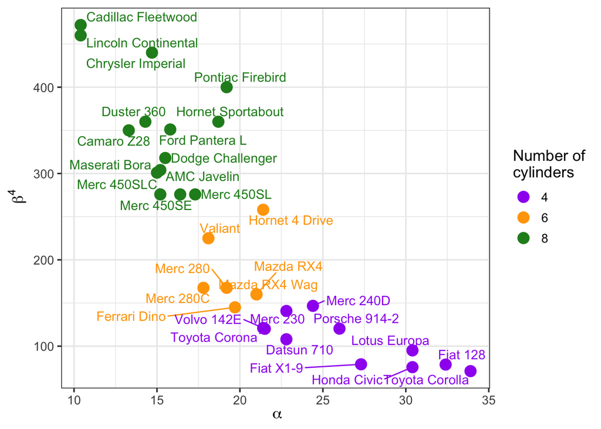

```r
## Using expression
ggplot(mycars,
       aes(x = mpg, y = disp, color = cyl, label = model)) +
    geom_point(size = 4) +
    geom_text_repel(min.segment.length = 0, max.overlaps = Inf) +
    scale_color_manual(values = c(`4` = "purple", `6` = "orange",
                                  `8` = "forestgreen"),
                       name = "Number of\ncylinders") +
    labs(x = expression(~ alpha), y = expression(~ beta ^ 4)) +
    theme_bw(base_size = 13)
```

or by using [Unicode characters](https://en.wikipedia.org/wiki/List_of_Unicode_characters#) characters (note that these may not be properly displayed unless the plot backend is set to Cairo):

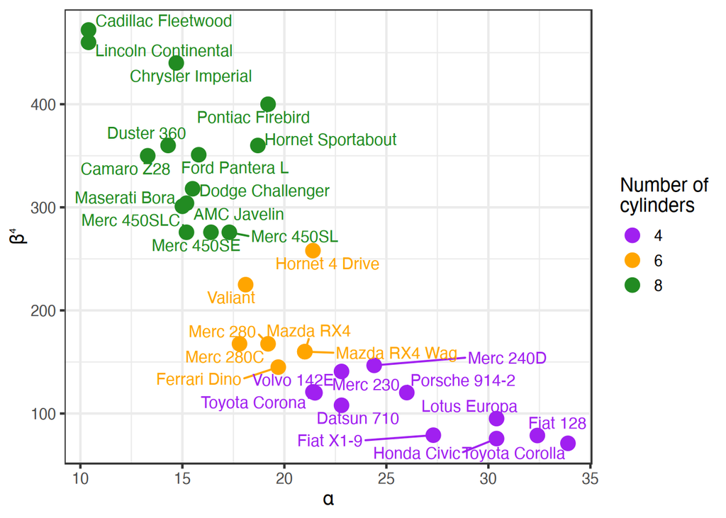

```r
## Using Unicode
ggplot(mycars,
       aes(x = mpg, y = disp, color = cyl, label = model)) +
    geom_point(size = 4) +
    geom_text_repel(min.segment.length = 0, max.overlaps = Inf) +
    scale_color_manual(values = c(`4` = "purple", `6` = "orange",
                                  `8` = "forestgreen"),
                       name = "Number of\ncylinders") +
    labs(x = "\U03B1", y = "\U03B2\U2074") +
    theme_bw(base_size = 13)
```

## Resources

- Some [useful examples](https://coderclub.w.uib.no/2015/05/07/expressions-in-r/) of using `expression` and `bquote` to add special characters to plot labels. Also see `?plotmath`.